# The Correlation Between Gender and Complaints Against Police Officers in NYC

## “The Correlation Between Gender and Complaints Against Police Officers in NYC”

Adina Scheinfeld

06/25/2021

The purpose of this project was to analyze the correlation between the gender and complaints against NYC police officers. Analysis was done to compare the association between the gender of the impacted person, the gender of the offending officer, and whether impacted people of one gender were more likely to have “action” taken as a result of their complaints than people of the other gender. The category of “action” includes actions such as the officer being found guilty, the officer pleading guilty, nolo contendere, the officer being dismissed, the officer being retained with discipline, and the officer receiving training. The category of “no action” includes the officer being found not guilty, the officer being retained without discipline, and the charge being dismissed. Analysis was also done to determine whether there was a correlation between the sex of the offending officer and whether a complaint was sustained.

All data used in this project was taken from the New York Civil Liberties Union. The data include incidents that occurred from 1985-2020. However, cases in which the outcome was not specified could not be used in this analysis. Additionally, cases that were still pending or in which the officer retired before a resolution were not included in the analysis.

```r
library(tidyverse)
library(lubridate)
library(scales)
theme_set(theme_bw())
```

```r
# read in findings data from OpenDataPhilly
nyc_incidents <-
  read_csv('data/nyc_incidents.csv')
# View(nyc_incidents)
```

```r
# select only needed columns
nyc_incidents_with_specific_columns <- nyc_incidents %>%
  select(OfficerGender, NYPDDisposition, ImpactedGender) %>%
  drop_na(NYPDDisposition)
# View(nyc_incidents_with_specific_columns)

# add a column with symbol to indicate the Outcome
# A = Action taken, N = No action taken
nyc_incidents_with_specific_columns <- nyc_incidents_with_specific_columns %>%
  mutate(Outcome = case_when(NYPDDisposition == "APU Closed: Previously adjudicated, with discipline" ~ "A",
                             NYPDDisposition == "APU Closed: Retained, with discipline" ~ "A",
                             NYPDDisposition == "APU Closed: Retained, without discipline" ~ "N",
                             NYPDDisposition == "APU Command Discipline" ~ "A",
                             NYPDDisposition == "APU Command Discipline B" ~ "A",
                             NYPDDisposition == "APU Dismissed" ~ "A",
                             NYPDDisposition == "APU Formalized Training" ~ "A",
                             NYPDDisposition == "APU Guilty" ~ "A",
                             NYPDDisposition == "APU Nolo contendere" ~ "A",
                             NYPDDisposition == "APU Not guilty" ~ "N",
                             NYPDDisposition == "APU Previously adjudicated, with discipline" ~ "A",
                             NYPDDisposition == "No Finding" ~ "N",
                             NYPDDisposition == "APU Retained, with discipline" ~ "A",
                             NYPDDisposition == "Charge Dismissed - DCT" ~ "N",
                             NYPDDisposition == "Charge Dismissed - OATH" ~ "N",
                             NYPDDisposition == "Command Discipline - A" ~ "A",
                             NYPDDisposition == "Command Discipline - B" ~ "A",
                             NYPDDisposition == "Formalized Training" ~ "A",
                             NYPDDisposition == "Guilty - DCT" ~ "A",
                             NYPDDisposition == "Negttn-Guilty" ~ "A",
                             NYPDDisposition == "Negttn-Nolo contendre" ~ "A",
                             NYPDDisposition == "No Disciplinary Action-DUP" ~ "N",
                             NYPDDisposition == "No Disciplinary Action-SOL" ~ "N",
                             NYPDDisposition == "Not Guilty - DCT" ~ "N",
                             NYPDDisposition == "Plead Guilty - DCT" ~ "A",
                             NYPDDisposition == "Plead Guilty - OATH" ~ "A")) %>%
  # remove cases in which the outcome is not specified
  drop_na(Outcome)
# View(nyc_incidents_with_specific_columns)
```

First, we analyzed the percentage of cases by impacted males for which action was taken versus the percentage of cases by impacted males for which no action was taken as compared with the percentage of cases by impacted females for which action was taken versus the percentage of cases by impacted females for which no action was taken. In other words, we analyzed the percentage of cases for which action was taken versus the percentage of cases for which no action was taken, given that the impacted person was a male, as compared with the percentage of cases for which action was taken versus the percentage of cases for which no action was taken, given that the impacted person was a female. Based on the graphs below, it seems that action was more likely to be taken for cases opened by females than for cases opened by males. Pearsons Chi-squared test was run to determine whether this difference was statistically significant. The result of the Chi-squared test was 0.0003701 which indicates, at a significance level of 0.05, that the gender of the impacted person and whether or not action was taken are not independent of each other.

```r
# count how many complaints had action taken for them vs no action taken, by impacted gender
nyc_incidents_by_impacted_gender <- nyc_incidents_with_specific_columns %>%
  filter((Outcome == "A" & ImpactedGender == "Male") |
           (Outcome == "A" & ImpactedGender == "Female") |
           (Outcome == "N" & ImpactedGender == "Male") |
           (Outcome == "N" & ImpactedGender == "Female")) %>%
  group_by(ImpactedGender, Outcome) %>%
  summarize(num_in_this_category = n())
# View(nyc_incidents_by_impacted_gender)
```

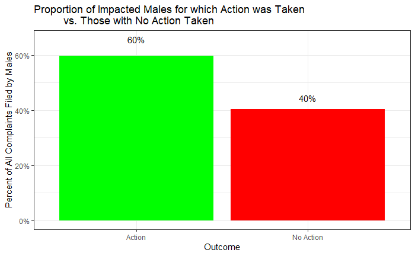

```r
# find the proportion of impacted males with action taken vs no action taken
nyc_incidents_by_impacted_males <- nyc_incidents_by_impacted_gender %>%
  filter(ImpactedGender == "Male") %>%
  mutate(proportion_of_impacted_males = num_in_this_category / sum(num_in_this_category))
# View(nyc_incidents_by_impacted_males)

# bar chart
nyc_incidents_by_impacted_males %>%
  ggplot(aes(x = Outcome, y = proportion_of_impacted_males)) +
  geom_bar(stat = "identity", fill = c("green", "red")) +
  # label each bar with the percentage
  geom_text(aes(label = percent(proportion_of_impacted_males)), position = position_stack(vjust = 1.1)) +
  # label y axis and set the y axis labels to be percents
  scale_y_continuous("Percent of All Complaints Filed by Males", labels = percent) +
  # label x axis and label each bar
  scale_x_discrete("Outcome", labels = c("Action", "No Action")) +
  # title the graph
  ggtitle("Proportion of Impacted Males for which Action was Taken
          vs. Those with No Action Taken")
```

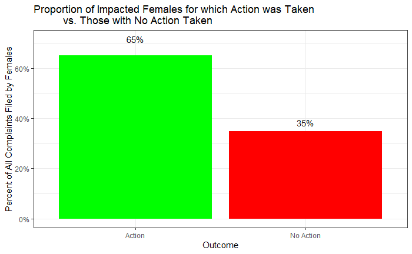

```r
# find the proportion of impacted males with action taken vs no action taken
nyc_incidents_by_impacted_females <- nyc_incidents_by_impacted_gender %>%
  filter(ImpactedGender == "Female") %>%
  mutate(proportion_of_impacted_females = num_in_this_category / sum(num_in_this_category))
# View(nyc_incidents_by_impacted_females)

# bar chart
nyc_incidents_by_impacted_females %>%
  ggplot(aes(x = Outcome, y = proportion_of_impacted_females)) +
  geom_bar(stat = "identity", fill = c("green", "red")) +
  # label each bar with the percentage
  geom_text(aes(label = percent(proportion_of_impacted_females)), position = position_stack(vjust = 1.1)) +
  # label y axis and set the y axis labels to be percents
  scale_y_continuous("Percent of All Complaints Filed by Females", labels = percent) +
  # label x axis and label each bar
  scale_x_discrete("Outcome", labels = c("Action", "No Action")) +
  # title the graph
  ggtitle("Proportion of Impacted Females for which Action was Taken
          vs. Those with No Action Taken")
```

```r
# create dataframe with genders and outcomes
nyc_incidents_with_counts_of_genders <- nyc_incidents_with_specific_columns %>%
  filter(ImpactedGender == "Male" | ImpactedGender == "Female")

# make a table with genders and counts to indicate whether or not action was taken
nyc_incidents_with_counts_of_genders_table <-
  table(nyc_incidents_with_counts_of_genders$ImpactedGender, nyc_incidents_with_counts_of_genders$Outcome)

# nyc_incidents_with_counts_of_genders_table

# run chi-squared test
chisq.test(nyc_incidents_with_counts_of_genders_table)
```

```
    Pearson's Chi-squared test with Yates' continuity correction

data:  nyc_incidents_with_counts_of_genders_table
X-squared = 12.677, df = 1, p-value = 0.0003701
```

Next, we analyzed the proportion of cases for impacted people of each gender with action versus no action divided also by the gender of the offending officer. Although there are slight differences between males and females, the differences do not appear to be statistically significant.

| —— | Action Taken | No Action Taken |
| --- | --- | --- |
| Impacted Male | 59.64% | 40.36% |
| Impacted Male | 60.63% | 39.37% |
| Impacted Female | 64.7% | 35.3% |
| Impacted Female | 67.0% | 33.0% |

Key:  
Filed against Male Officer  
Filed against Female Officer

```r
# count how many complaints resulted in action vs no action per gender
nyc_incidents_by_impacted_gender_and_officer_gender <-
  nyc_incidents_with_specific_columns %>%
  group_by(ImpactedGender, Outcome) %>%
  filter((Outcome == "A" & ImpactedGender == "Male") |
           (Outcome == "A" & ImpactedGender == "Female") |
           (Outcome == "N" & ImpactedGender == "Male") |
           (Outcome == "N" & ImpactedGender == "Female")) %>%
  group_by(ImpactedGender, OfficerGender, Outcome) %>%
  summarize(num_in_this_category = n())
# View(nyc_incidents_by_impacted_gender_and_officer_gender)
```

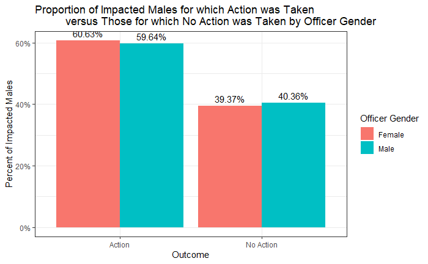

```r
# find proportion of complaints by impacted males with action vs no action by officer gender
impacted_male_and_officer_gender <-
  nyc_incidents_by_impacted_gender_and_officer_gender %>%
  # keep only male complainants
  filter(ImpactedGender == "Male") %>%
  # calculate the proportion
  mutate(proportion_in_this_category = num_in_this_category / sum(num_in_this_category))
# View(impacted_male_and_officer_gender)

# bar chart
impacted_male_and_officer_gender %>% ggplot(aes(x = Outcome,
                                                y = proportion_in_this_category,
                                                fill = OfficerGender)) +
  geom_bar(stat = "identity", position = "dodge") +
  # label each bar with the percentage
  geom_text(aes(label = percent(proportion_in_this_category)),
            position = position_dodge(width = 0.9), vjust = -0.5) +
  # set the y axis labels to be percents
  scale_y_continuous("Percent of Impacted Males", labels = percent) +
  # label the x axis
  scale_x_discrete("Outcome", labels = c("Action", "No Action")) +
  scale_fill_discrete("Officer Gender", labels = c("Female", "Male")) +
  # title the graph
  ggtitle("Proportion of Impacted Males for which Action was Taken
          versus Those for which No Action was Taken by Officer Gender")
```

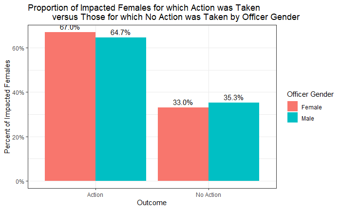

```r
# find proportion of complaints by impacted females with action vs no action by officer gender
impacted_female_and_officer_gender <-
  nyc_incidents_by_impacted_gender_and_officer_gender %>%
  # keep only female complainants
  filter(ImpactedGender == "Female") %>%
  # calculate the proportion
  mutate(proportion_in_this_category = num_in_this_category / sum(num_in_this_category))
# View(impacted_female_and_officer_gender)

# bar chart
impacted_female_and_officer_gender %>% ggplot(aes(x = Outcome,
                                                y = proportion_in_this_category,
                                                fill = OfficerGender)) +
  geom_bar(stat = "identity", position = "dodge") +
  # label each bar with the percentage
  geom_text(aes(label = percent(proportion_in_this_category)),
            position = position_dodge(width = 0.9), vjust = -0.5) +
  # set the y axis labels to be percents
  scale_y_continuous("Percent of Impacted Females", labels = percent) +
  # label the x axis
  scale_x_discrete("Outcome", labels = c("Action", "No Action")) +
  scale_fill_discrete("Officer Gender", labels = c("Female", "Male")) +
  # title the graph
  ggtitle("Proportion of Impacted Females for which Action was Taken
          versus Those for which No Action was Taken by Officer Gender")
```

Next, we analyzed the proportion cases in which action was taken for impacted males as compared with the proportion of cases in which action was taken for impacted females. In other words, given that action was taken, what was the probability that the impacted person was male versus female. As evident from the pie chart below, it seems that action was more likely to be taken for an impacted male than for an impacted female. However, further analysis is required to determine if this finding is significant or if there is another factor, such as males opening more cases than females, that may account for this difference in proportion.

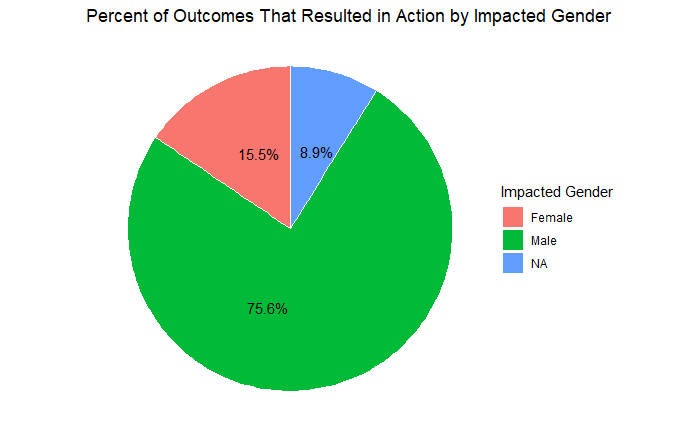

```r
# find the proportion of action vs no action by gender
nyc_action_per_gender <- nyc_incidents_with_specific_columns %>%
  group_by(ImpactedGender) %>%
  # keep only impacted people for which action was taken
  filter(Outcome == "A") %>%
  mutate(ImpactedGender = case_when((ImpactedGender == "Male" ~ "Male"),
                                    (ImpactedGender == "Female" ~ "Female"),
                                    (is.na(ImpactedGender) |
                                       ImpactedGender != "Male" & ImpactedGender != "Female") ~ "NA")) %>%
  # count the number of outcomes with action per gender
  summarize(num_complaints = n()) %>%
  # calculate the proportion of outcomes with action by each sex
  mutate(proportion_of_sustained_findings = num_complaints / sum(num_complaints))
#View(nyc_action_per_gender)

# pie chart
nyc_action_per_gender  %>%
  ggplot(aes(x = "", y = proportion_of_sustained_findings, fill = ImpactedGender)) +
  geom_bar(stat = "identity", width = 1, color = "white") +
  coord_polar("y", start = 0) +
  # label each segment in the chart
  geom_text(aes(label = percent(proportion_of_sustained_findings)), position = position_stack(vjust = 0.6)) +
  theme_void() +
  # set the key
  scale_fill_discrete("Impacted Gender",
                      labels = c("Female", "Male")) +
  # title the chart
  ggtitle("Percent of Outcomes That Resulted in Action by Impacted Gender")
```

Further analysis into percentage of all cases opened by males as compared with the percentage of all cases opened by females indicated that males are significantly more likely to file complaints than females, so the discrepancy between the proportion of cases in which action was taken for impacted males as compared with the proportion of cases in which action was taken for impacted females may be due to the fact that males open more cases than females. As evident from the pie chart below, the difference in proportion between the total number of cases opened by males versus females is nearly identical to the difference in proportion between the number of cases for which action was taken for impacted males versus impacted females.

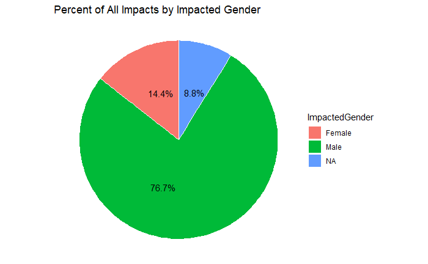

```r
# find the proportion of all impacts per gender
nyc_impacts_per_gender <- nyc_incidents_with_specific_columns %>%
  group_by(ImpactedGender) %>%
    mutate(ImpactedGender = case_when((ImpactedGender == "Male" ~ "Male"),
                                    (ImpactedGender == "Female" ~ "Female"),
                                    (is.na(ImpactedGender) |
                                       ImpactedGender != "Male" & ImpactedGender != "Female") ~ "NA")) %>%
  # count the number of all impacts per gender
  summarize(num_complaints = n()) %>%
  # calculate the proportion of all impacts per gender
  mutate(proportion_of_all_findings = num_complaints / sum(num_complaints))
# View(nyc_impacts_per_gender)

# pie chart
nyc_impacts_per_gender  %>%
  ggplot(aes(x = "", y = proportion_of_all_findings, fill = ImpactedGender)) +
  geom_bar(stat = "identity", width = 1, color = "white") +
  coord_polar("y", start = 0) +
  # label each segment in the chart
  geom_text(aes(label = percent(proportion_of_all_findings)), position = position_stack(vjust = 0.6)) +
  theme_void() +
  # set the key
  scale_fill_discrete("ImpactedGender",
                      labels = c("Female", "Male")) +
  # title the chart
  ggtitle("Percent of All Impacts by Impacted Gender")
```